# **Milestone 2**

We have built two Convolutional Neural Network architectures in Milestone 1. Here, we will further try to achieve better performance by increasing the number of parameters/weights. Therefore, we will start this Milestone with three popular Transfer Learning architectures, namely, VGG16, ResNet v2, and Efficient Net. Please feel free to explore other pre-trained models as well. Link to Keras documentation for pre-trained models - https://keras.io/api/applications/

**Note:** We will mount our drive and import our dataset once again for Milestone 2.

## **Mounting the Drive**

**NOTE:** Please use Google Colab from your browser for this notebook. **Google.colab is not a library that can be downloaded locally on your device.**

```python
# Mounting the drive
from google.colab import drive
drive.mount('/content/drive')
```

```python
%%shell
jupyter nbconvert --to html '/content/drive/MyDrive/Capstone_project/Milestone_2/AnjuPandey_Facial_Emotion_Detection_Milestone+2.ipynb'
```

[output not shown]

[output cut: 107 more lines]

[output not shown]

[output not shown]

## **Importing the Libraries**

```python
import zipfile
import matplotlib.pyplot as plt
import numpy as np
import pandas as pd
import seaborn as sns
import os

# Importing Deep Learning Libraries
from tensorflow.keras.applications.vgg16 import VGG16
from tensorflow.keras import Model
from tensorflow.keras.preprocessing.image import load_img, img_to_array
from tensorflow.keras.preprocessing.image import ImageDataGenerator
from tensorflow.keras.layers import Dense, Input, Dropout, GlobalAveragePooling2D, Flatten, Conv2D, BatchNormalization, Activation, MaxPooling2D, LeakyReLU
from tensorflow.keras.models import Model, Sequential
from tensorflow.keras.optimizers import Adam, SGD, RMSprop
```

### **Let us load the data**

**Note:**

- You must download the dataset from the link provided on Olympus and upload the same on your Google drive before executing the code in the next cell.
- In case of any error, please make sure that the path of the file is correct as the path may be different for you.

```python
# Storing the path of the data file from the Google drive
path = 'Facial_emotion_images.zip'

# The data is provided as a zip file so we need to extract the files from the zip file
with zipfile.ZipFile(path, 'r') as zip_ref:
    zip_ref.extractall()
```

```python
picture_size = 48
folder_path = "Facial_emotion_images/"
```

## **Transfer Learning Architectures**

In this section, we will create several Transfer Learning architectures. For the pre-trained models, we will select three popular architectures namely, VGG16, ResNet v2, and Efficient Net. The difference between these architectures and the previous architectures is that these will require 3 input channels while the earlier ones worked on 'grayscale' images. Therefore, we need to create new DataLoaders.

### **Creating our Data Loaders for Transfer Learning Architectures**

In this section, we are creating data loaders that we will use as inputs to our Neural Network. Unlike in Milestone 1, we will have to go with color_mode = 'rgb' as this is the required format for the transfer learning architectures.

```python
batch_size  = 32
img_size =48
col_mode='rgb'

datagen_train = ImageDataGenerator(horizontal_flip = True,
                                    brightness_range = (0., 2.),
                                    rescale = 1./255,
                                    shear_range = 0.3)

train_set = datagen_train.flow_from_directory(folder_path + "train",
                                              target_size = (img_size, img_size),
                                              color_mode = col_mode,
                                              batch_size = batch_size,
                                              class_mode = 'categorical',
                                              classes = ['happy', 'sad', 'neutral', 'surprise'],
                                              shuffle = True)



datagen_validation = ImageDataGenerator(horizontal_flip = True,
                                    brightness_range = (0., 2.),
                                    rescale = 1./255,
                                    shear_range = 0.3)

validation_set = datagen_validation.flow_from_directory(folder_path + "validation",
                                              target_size = (img_size, img_size),
                                              color_mode = col_mode,
                                              batch_size = batch_size,
                                              class_mode = 'categorical',
                                              classes = ['happy', 'sad', 'neutral', 'surprise'],
                                              shuffle = True)


datagen_test = ImageDataGenerator(horizontal_flip = True,
                                    brightness_range = (0., 2.),
                                    rescale = 1./255,
                                    shear_range = 0.3)

test_set = datagen_test.flow_from_directory(folder_path + "test",
                                              target_size = (img_size, img_size),
                                              color_mode = col_mode,
                                              batch_size = batch_size,
                                              class_mode = 'categorical',
                                              classes = ['happy', 'sad', 'neutral', 'surprise'],
                                              shuffle = True)
```

```
Found 15109 images belonging to 4 classes.
Found 4977 images belonging to 4 classes.
Found 128 images belonging to 4 classes.
```

## **VGG16 Model**

### **Importing the VGG16 Architecture**

```python
from tensorflow.keras.applications.vgg16 import VGG16
from tensorflow.keras import Model

vgg = VGG16(include_top = False, weights = 'imagenet', input_shape = (img_size, img_size, 3))
vgg.summary()
```

```
Downloading data from https://storage.googleapis.com/tensorflow/keras-applications/vgg16/vgg16_weights_tf_dim_ordering_tf_kernels_notop.h5
Model: "vgg16"
_________________________________________________________________
 Layer (type)                Output Shape              Param #
=================================================================
 input_1 (InputLayer)        [(None, 48, 48, 3)]       0

 block1_conv1 (Conv2D)       (None, 48, 48, 64)        1792

 block1_conv2 (Conv2D)       (None, 48, 48, 64)        36928

 block1_pool (MaxPooling2D)  (None, 24, 24, 64)        0

 block2_conv1 (Conv2D)       (None, 24, 24, 128)       73856

 block2_conv2 (Conv2D)       (None, 24, 24, 128)       147584

 block2_pool (MaxPooling2D)  (None, 12, 12, 128)       0

 block3_conv1 (Conv2D)       (None, 12, 12, 256)       295168

 block3_conv2 (Conv2D)       (None, 12, 12, 256)       590080

 block3_conv3 (Conv2D)       (None, 12, 12, 256)       590080

 block3_pool (MaxPooling2D)  (None, 6, 6, 256)         0

 block4_conv1 (Conv2D)       (None, 6, 6, 512)         1180160

 block4_conv2 (Conv2D)       (None, 6, 6, 512)         2359808

 block4_conv3 (Conv2D)       (None, 6, 6, 512)         2359808

 block4_pool (MaxPooling2D)  (None, 3, 3, 512)         0

 block5_conv1 (Conv2D)       (None, 3, 3, 512)         2359808

 block5_conv2 (Conv2D)       (None, 3, 3, 512)         2359808

 block5_conv3 (Conv2D)       (None, 3, 3, 512)         2359808

 block5_pool (MaxPooling2D)  (None, 1, 1, 512)         0

=================================================================
Total params: 14,714,688
Trainable params: 14,714,688
Non-trainable params: 0
_________________________________________________________________
```

### **Model Building**

- In this model, we will import till the **'block5_pool'** layer of the VGG16 model. You can scroll down in the model summary and look for 'block5_pool'. You can choose any other layer as well.
- Then we will add a Flatten layer, which receives the output of the 'block5_pool' layer as its input.
- We will add a few Dense layers and use 'relu' activation function on them.
- You may use Dropout and BatchNormalization layers as well.
- Then we will add our last dense layer, which must have 4 neurons and a 'softmax' activation function.

```python
transfer_layer = vgg.get_layer('block5_pool')
vgg.trainable = False
for l in vgg.layers:
  l.trainable=False

# Add classification layers on top of it
# Flattenning the output from the 3rd block of the VGG16 model
x = Flatten()(transfer_layer.output)

# Adding a Dense layer with 256 neurons
x = Dense(256, activation = 'relu')(x)

# Add a Dense Layer with 128 neurons
x = Dense(128, activation = 'relu')(x)

# Add a DropOut layer with Drop out ratio of 0.3
x = Dropout(0.3)(x)

# Add a Dense Layer with 64 neurons
x = Dense(64, activation = 'relu')(x)

# Add a Batch Normalization layer
x = BatchNormalization()(x)

# Adding the final dense layer with 4 neurons and use 'softmax' activation
pred = Dense(4, activation='softmax')(x)

vggmodel = Model(vgg.input, pred) # Initializing the model
```

### **Compiling and Training the VGG16 Model**

```python
from keras.callbacks import ModelCheckpoint, EarlyStopping, ReduceLROnPlateau

checkpoint = ModelCheckpoint("./vggmodel.h5", monitor = 'val_accuracy', verbose = 1, save_best_only = True, mode = 'max')

early_stopping = EarlyStopping(monitor = 'val_accuracy',
                          min_delta = 0,
                          patience = 3,
                          verbose = 1,
                          restore_best_weights = True
                          )

reduce_learningrate = ReduceLROnPlateau(monitor = 'val_accuracy',
                              factor = 0.2,
                              patience = 3,
                              verbose = 1,
                              min_delta = 0.0001)

callbacks_list = [early_stopping, checkpoint, reduce_learningrate]

epochs = 20
```

```python
# Write your code to compile the vggmodel. Use categorical crossentropy as the loss function,
#Adam Optimizer with 0.001 learning rate, and set metrics to 'accuracy'.
#vggmodel.summary()
vggmodel.compile(optimizer=Adam(0.001),
                  loss='categorical_crossentropy',
                  metrics=['accuracy'])
```

```python
# Write your code to fit your model.
#Use train_set as the training data and validation_set as the validation data.
#Train the model for 20 epochs.

history = vggmodel.fit(train_set,
                       validation_data=validation_set,
                       epochs=20,
                       callbacks=callbacks_list)
```

```
Epoch 1: val_accuracy improved from -inf to 0.47157, saving model to ./vggmodel.h5
Epoch 2: val_accuracy improved from 0.47157 to 0.47679, saving model to ./vggmodel.h5
Epoch 3: val_accuracy improved from 0.47679 to 0.49086, saving model to ./vggmodel.h5
Epoch 4: val_accuracy did not improve from 0.49086
Epoch 5: val_accuracy improved from 0.49086 to 0.50251, saving model to ./vggmodel.h5
Epoch 6: val_accuracy did not improve from 0.50251
Epoch 7: val_accuracy did not improve from 0.50251

Epoch 8: val_accuracy did not improve from 0.50251

Epoch 8: ReduceLROnPlateau reducing learning rate to 0.00020000000949949026.
Epoch 8: early stopping
```

## **Training Result:**

Model was set to train for 20 epochs. But after 5th epochs, model’s validation accuracy was not improving therefore after 8th epoch training was stopped. At 8th epoch, model’s accuracy level was as follows:  
**Training Data: 49.75%**  
**Validation Data:49.41%**

### **Evaluating the VGG16 model**

```python
#evaluate model performance with test data
vggmodel.evaluate(test_set)
```

```
[1.1861389875411987, 0.4375]
```

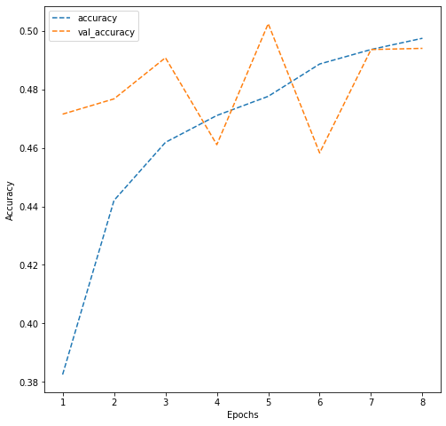

```python
# Plotting the training and validation data accuracies

dict_hist = history.history

list_ep = [i for i in range(1, 9)]

plt.figure(figsize = (8, 8))

plt.plot(list_ep, dict_hist['accuracy'], ls = '--', label = 'accuracy')

plt.plot(list_ep, dict_hist['val_accuracy'], ls = '--', label = 'val_accuracy')

plt.ylabel('Accuracy')

plt.xlabel('Epochs')

plt.legend()

plt.show()
```

**Plot Explaination**  
Kind of gradual increase observed in training data accuracy level and lot of fluctuation in validation data accuracy level is indicative of overfitting model.

**Prediction:**  
Let’s check if model can correctly classify a simple happy face.

```
Model's prediction= neutral
```

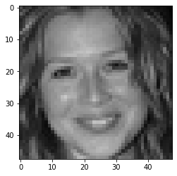

```python
#Predict images with vgg16model
from keras_preprocessing.image import load_img
from keras_preprocessing.image import img_to_array
from keras.applications.vgg16 import preprocess_input

import pandas as pd
label_map = (test_set.class_indices)
image = load_img('15710.jpg', target_size=(48, 48,3)) #Load image
plt.imshow(image)
image = img_to_array(image) # Convert to numpy array
image = image.reshape((1, image.shape[0], image.shape[1], image.shape[2])) # reshape data for the model
image = preprocess_input(image)
pred = vggmodel.predict(image)

print("Model's prediction=",list(label_map.keys())[list(label_map.values()).index(np.argmax(pred))])
```

**Prediction Result (VGG16):**  
Provided image is a ‘happy’ face where lip corners are slightly up, eyes are little squinched. These are high level features, but our model is failing to extract these features. Hence we can say that though its having approx. 43% accuracy, it’s not performing well at all and it cannot be used for classification until modified with better architecture.

## **Another VGG16 model**

```python
for l in vgg.layers:
  l.trainable=False

vgg_model_1=Sequential()

vgg_model_1.add(vgg.get_layer('block4_pool'))
vgg_model_1.add(Flatten())
vgg_model_1.add(Dense(512,activation='relu'))
vgg_model_1.add(Dense(256,activation='relu'))
vgg_model_1.add(Dense(128,activation='relu'))
vgg_model_1.add(Dense(4, activation="softmax"))
vgg_model_1.compile(optimizer=Adam(0.001), loss='categorical_crossentropy',metrics=['accuracy'])
```

```python
#This callback will stop the training when there is no improvement in
#validation accuracy for cosecutive 5 epochs.
callback_vgg_model_1 = EarlyStopping(monitor='val_accuracy', patience=5)
```

```python
#train this model
history_vgg_model_1=vgg_model_1.fit(train_set,
                                    validation_data=validation_set,
                                    epochs = 35,
                                    callbacks=[callback_vgg_model_1])
```

```python
#evaluate new model
vgg_model_1.evaluate(test_set)
```

```
[1.1625655889511108, 0.5078125]
```

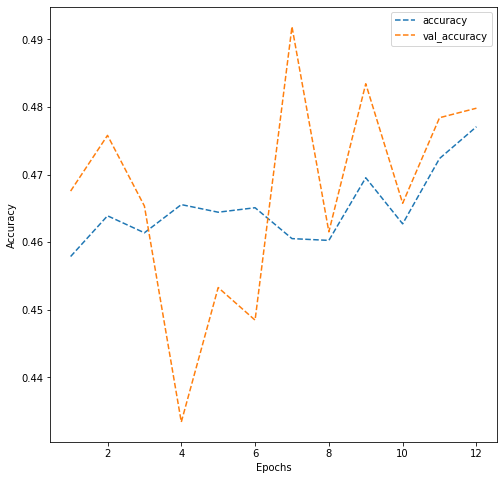

```python
# Plotting the training and validation data accuracies

dict_hist = history_vgg_model_1.history

list_ep = [i for i in range(1, 13)]

plt.figure(figsize = (8, 8))

plt.plot(list_ep, dict_hist['accuracy'], ls = '--', label = 'accuracy')

plt.plot(list_ep, dict_hist['val_accuracy'], ls = '--', label = 'val_accuracy')

plt.ylabel('Accuracy')

plt.xlabel('Epochs')

plt.legend()

plt.show()
```

```
Model's prediction= neutral
```

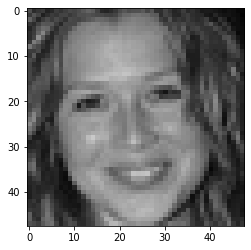

```python
#Predict images with vgg16model
from keras_preprocessing.image import load_img
from keras_preprocessing.image import img_to_array
from keras.applications.vgg16 import preprocess_input

import pandas as pd
label_map = (test_set.class_indices)
image = load_img('15710.jpg', target_size=(48, 48,3)) #Load image
plt.imshow(image)
image = img_to_array(image) # Convert to numpy array
image = image.reshape((1, image.shape[0], image.shape[1], image.shape[2])) # reshape data for the model
image = preprocess_input(image)
pred = vgg_model_1.predict(image)

print("Model's prediction=",list(label_map.keys())[list(label_map.values()).index(np.argmax(pred))])
```

**Result & Comparision:**

Though above model is performing better than the previous model and its accuracy level on test data is 50% but it is unable to extract the important features of image and its failing while predicting.

**Think About It:**

- What do you infer from the general trend in the training performance?
- Is the training accuracy consistently improving?
- Is the validation accuracy also improving similarly?

**Observations and Insights:__**

If we see the accuracy level plots, training data accuracy is increasing with no or little fluctuations whereas validation data accuracy has lot of fluctuations.  
For model(vggmodel_1) ,accuracy level was not going up hence training was stopped after 12th epoch.  
As training data accuracy level is rising but val_accuracy is not so both the models are going to overfit the training data, so we need more dropout and batchnormalization layers and certainly different model architecture is needed.

**Note: You can even go back and build your own architecture on top of the VGG16 Transfer layer and see if you can improve the performance**

## **ResNet V2 Model**

```python
import tensorflow as tf
import tensorflow.keras.applications as ap
from tensorflow.keras import Model

Resnet = ap.ResNet101(include_top = False, weights = "imagenet", input_shape=(img_size,img_size,3))
Resnet.summary()
```

```
Downloading data from https://storage.googleapis.com/tensorflow/keras-applications/resnet/resnet101_weights_tf_dim_ordering_tf_kernels_notop.h5
Model: "resnet101"
__________________________________________________________________________________________________
 Layer (type)                   Output Shape         Param #     Connected to
==================================================================================================
 input_2 (InputLayer)           [(None, 48, 48, 3)]  0           []

 conv1_pad (ZeroPadding2D)      (None, 54, 54, 3)    0           ['input_2[0][0]']

 conv1_conv (Conv2D)            (None, 24, 24, 64)   9472        ['conv1_pad[0][0]']

 conv1_bn (BatchNormalization)  (None, 24, 24, 64)   256         ['conv1_conv[0][0]']

 conv1_relu (Activation)        (None, 24, 24, 64)   0           ['conv1_bn[0][0]']

 pool1_pad (ZeroPadding2D)      (None, 26, 26, 64)   0           ['conv1_relu[0][0]']

 pool1_pool (MaxPooling2D)      (None, 12, 12, 64)   0           ['pool1_pad[0][0]']

 conv2_block1_1_conv (Conv2D)   (None, 12, 12, 64)   4160        ['pool1_pool[0][0]']

 conv2_block1_1_bn (BatchNormal  (None, 12, 12, 64)  256         ['conv2_block1_1_conv[0][0]']
 ization)

 conv2_block1_1_relu (Activatio  (None, 12, 12, 64)  0           ['conv2_block1_1_bn[0][0]']
 n)

 conv2_block1_2_conv (Conv2D)   (None, 12, 12, 64)   36928       ['conv2_block1_1_relu[0][0]']

 conv2_block1_2_bn (BatchNormal  (None, 12, 12, 64)  256         ['conv2_block1_2_conv[0][0]']
 ization)

 conv2_block1_2_relu (Activatio  (None, 12, 12, 64)  0           ['conv2_block1_2_bn[0][0]']
 n)

 conv2_block1_0_conv (Conv2D)   (None, 12, 12, 256)  16640       ['pool1_pool[0][0]']

 conv2_block1_3_conv (Conv2D)   (None, 12, 12, 256)  16640       ['conv2_block1_2_relu[0][0]']

 conv2_block1_0_bn (BatchNormal  (None, 12, 12, 256)  1024       ['conv2_block1_0_conv[0][0]']
```

[output cut: 847 more lines]

```
 conv5_block3_3_conv (Conv2D)   (None, 2, 2, 2048)   1050624     ['conv5_block3_2_relu[0][0]']

 conv5_block3_3_bn (BatchNormal  (None, 2, 2, 2048)  8192        ['conv5_block3_3_conv[0][0]']
 ization)

 conv5_block3_add (Add)         (None, 2, 2, 2048)   0           ['conv5_block2_out[0][0]',
                                                                  'conv5_block3_3_bn[0][0]']

 conv5_block3_out (Activation)  (None, 2, 2, 2048)   0           ['conv5_block3_add[0][0]']

==================================================================================================
Total params: 42,658,176
Trainable params: 42,552,832
Non-trainable params: 105,344
__________________________________________________________________________________________________
```

### **Model Building**

- In this model, we will import till the **'conv5_block3_add'** layer of the ResNet model. You can scroll down in the model summary and look for 'conv5_block3_add'. You can choose any other layer as well.
- Then we will add a Flatten layer, which receives the output of the 'conv5_block3_add' layer as its input.
- We will add a few Dense layers and use 'relu' activation function on them.
- You may use Dropout and BatchNormalization layers as well.
- Then we will add our last dense layer, which must have 4 neurons and a 'softmax' activation function.

```python
transfer_layer_Resnet = Resnet.get_layer('conv5_block3_add')
Resnet.trainable=False
for l in Resnet.layers:
  l.trainable=False

# Add classification layers on top of it
x = Flatten()(transfer_layer_Resnet.output)

# Add a Dense layer with 256 neurons
x = Dense(256, activation = 'relu')(x)

# Add a Dense Layer with 128 neurons
x = Dense(128, activation = 'relu')(x)

# Add a DropOut layer with Drop out ratio of 0.3
x = Dropout(0.3)(x)

# Add a Dense Layer with 64 neurons
x = Dense(64, activation = 'relu')(x)

# Add a Batch Normalization layer
x = BatchNormalization()(x)

# Add the final dense layer with 4 neurons and use a 'softmax' activation
pred = Dense(4, activation = 'softmax')(x)

resnetmodel = Model(Resnet.input, pred) # Initializing the model
```

### **Compiling and Training the Model**

```python
from keras.callbacks import ModelCheckpoint, EarlyStopping, ReduceLROnPlateau

checkpoint = ModelCheckpoint("./Resnetmodel.h5", monitor = 'val_accuracy', verbose = 1, save_best_only = True, mode = 'max')

early_stopping = EarlyStopping(monitor = 'val_accuracy',
                          min_delta = 0,
                          patience = 3,
                          verbose = 1,
                          restore_best_weights = True
                          )

reduce_learningrate = ReduceLROnPlateau(monitor = 'val_accuracy',
                              factor = 0.2,
                              patience = 3,
                              verbose = 1,
                              min_delta = 0.0001)

callbacks_list = [early_stopping, checkpoint,reduce_learningrate]

epochs = 20
```

```python
# Write your code to compile your resnetmodel.
# Use categorical crossentropy as your loss function, Adam Optimizer with 0.001 learning rate,
# and set your metrics to 'accuracy'.
resnetmodel.compile(optimizer=Adam(0.001),
                    loss='categorical_crossentropy',
                    metrics=['accuracy'])
```

```python
# Write your code to fit your model.
# Use train_set as your training data and validation_set as your validation data.
# Train your model for 20 epochs.
history = resnetmodel.fit(train_set,
                          validation_data=validation_set,
                          epochs=20,
                          callbacks=[callbacks_list])
```

```
Epoch 1: val_accuracy improved from -inf to 0.16014, saving model to ./Resnetmodel.h5
Epoch 2: val_accuracy improved from 0.16014 to 0.24432, saving model to ./Resnetmodel.h5
Epoch 3: val_accuracy did not improve from 0.24432
Epoch 4: val_accuracy did not improve from 0.24432

Epoch 5: val_accuracy did not improve from 0.24432

Epoch 5: ReduceLROnPlateau reducing learning rate to 0.00020000000949949026.
Epoch 5: early stopping
```

### **Evaluating the ResNet Model**

```python
# Write your code to evaluate model performance on the test set
resnetmodel.evaluate(test_set)
```

```
[1.3883274793624878, 0.25]
```

**Result:**  
val_accuracy was not improving therefore model training was stopped after 5th epoch. Model’s accuracy on test data is 25%.

## **Another ResNet Model (Name-resnetmodel_2)**

Lets build another ResNet model (Name- resnetmodel_2) and compare the performance with previously build model(resnetmodel).

In seperate investigation, after picking each layer and comparing the performance, it was observed that if we transfer model architecture till conv3_block4_out and build another model on top of it then it provides better result.

No hidden layers will be added. We will add only classification layer.

```python
Resnet = ap.ResNet101(include_top = False, weights = "imagenet",
                      input_shape=(img_size,img_size,3))

transfer_layer_Resnet = Resnet.get_layer('conv3_block4_out')
Resnet.trainable=False
for l in Resnet.layers:
  l.trainable=False

resnetmodel_2=Sequential()
resnetmodel_2.add(transfer_layer_Resnet)
resnetmodel_2.add(Flatten())
resnetmodel_2.add(Dense(4,activation = 'softmax'))

resnetmodel_2.compile(optimizer=Adam(0.001),
                      loss='categorical_crossentropy',
                      metrics=['accuracy'])
```

```python
# train resnetmodel_2
# Write your code to fit your model. Use train_set as your training data and validation_set as your validation data. Train your model for 20 epochs.
history_2 = resnetmodel_2.fit(train_set,
                              validation_data=validation_set,
                              epochs=5)
```

```python
#Evaluate resnetmodel_2
resnetmodel_2.evaluate(test_set)
```

```
[1.2241045236587524, 0.4921875]
```

**Result comparison** lets compare the result of both the models for 5 epochs.

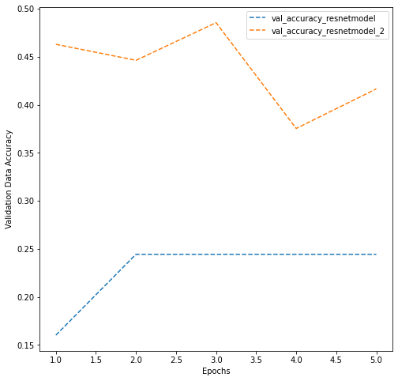

```python
# Plotting the accuracies

dict_hist = history.history
dict_hist2 = history_2.history

list_ep = [i for i in range(1, 6)]

plt.figure(figsize = (8, 8))

plt.plot(list_ep, dict_hist['val_accuracy'], ls = '--', label = 'val_accuracy_resnetmodel')

plt.plot(list_ep, dict_hist2['val_accuracy'], ls = '--', label = 'val_accuracy_resnetmodel_2')
plt.ylabel('Validation Data Accuracy')

plt.xlabel('Epochs')

plt.legend()

plt.show()
```

Plot and training result indicate that resnetmodel_2 is performing better.

Let’s check if these models can predict the expression accurately.

```
WARNING:matplotlib.image:Clipping input data to the valid range for imshow with RGB data ([0..1] for floats or [0..255] for integers).
```

[figure not shown]

```
         Happy Face
```

```
WARNING:matplotlib.image:Clipping input data to the valid range for imshow with RGB data ([0..1] for floats or [0..255] for integers).
```

```
resnetmodel Model's prediction= neutral
resnetmodel_2 Model's prediction= surprise
```

[figure not shown]

```
         Sad Face
```

```
WARNING:matplotlib.image:Clipping input data to the valid range for imshow with RGB data ([0..1] for floats or [0..255] for integers).
```

```
resnetmodel Model's prediction= neutral
resnetmodel_2 Model's prediction= surprise
```

[figure not shown]

```
         Neutral Face
```

```
WARNING:matplotlib.image:Clipping input data to the valid range for imshow with RGB data ([0..1] for floats or [0..255] for integers).
```

```
resnetmodel Model's prediction= neutral
resnetmodel_2 Model's prediction= neutral
```

[figure not shown]

```
         Surprise Face
resnetmodel Model's prediction= neutral
resnetmodel_2 Model's prediction= surprise
```

```python
# lets predict the face expression.
# will provide images for each expression (happy,sad,surprise and neutral)

#Predict images with resnetmodel and resnetmodel_2
from keras_preprocessing.image import load_img
from keras_preprocessing.image import img_to_array
from keras.applications.vgg16 import preprocess_input

label_map = (test_set.class_indices)

imageH = load_img('15730.jpg', target_size=(48, 48,3))
imageH = img_to_array(imageH)
imageH = imageH.reshape(( imageH.shape[0], imageH.shape[1], imageH.shape[2]))
imageH = preprocess_input(imageH)

images_list = []
images_list.append(np.array(imageH))
x = np.asarray(images_list)
plt.imshow(imageH)
plt.show()
print("         Happy Face          ")
pred = resnetmodel.predict(x)
pred_2 = resnetmodel_2.predict(x)

print("resnetmodel Model's prediction=",list(label_map.keys())[list(label_map.values()).index(np.argmax(pred))])
print("resnetmodel_2 Model's prediction=",list(label_map.keys())[list(label_map.values()).index(np.argmax(pred_2))])


imageSD = load_img('6992.jpg', target_size=(48, 48,3)) #Load image
imageSD = img_to_array(imageSD) # Convert to numpy array
imageSD = imageSD.reshape(( imageSD.shape[0], imageSD.shape[1], imageSD.shape[2])) # reshape data for the model
imageSD = preprocess_input(imageSD)
images_list = []
images_list.append(np.array(imageSD))
x = np.asarray(images_list)

plt.imshow(imageSD)
plt.show()
print("         Sad Face          ")
pred = resnetmodel.predict(x)
pred_2 = resnetmodel_2.predict(x)
print("resnetmodel Model's prediction=",list(label_map.keys())[list(label_map.values()).index(np.argmax(pred))])
print("resnetmodel_2 Model's prediction=",list(label_map.keys())[list(label_map.values()).index(np.argmax(pred_2))])


imageN = load_img('7278.jpg', target_size=(48, 48,3)) #Load image
imageN = img_to_array(imageN) # Convert to numpy array
imageN = imageN.reshape(( imageN.shape[0], imageN.shape[1], imageN.shape[2])) # reshape data for the model
imageN = preprocess_input(imageN)
images_list = []
images_list.append(np.array(imageN))
x = np.asarray(images_list)

plt.imshow(imageN)
plt.show()
print("         Neutral Face          ")
pred = resnetmodel.predict(x)
pred_2 = resnetmodel_2.predict(x)
print("resnetmodel Model's prediction=",list(label_map.keys())[list(label_map.values()).index(np.argmax(pred))])
print("resnetmodel_2 Model's prediction=",list(label_map.keys())[list(label_map.values()).index(np.argmax(pred_2))])


imageSR = load_img('208.jpg', target_size=(48, 48,3)) #Load image
imageSR = img_to_array(imageSR) # Convert to numpy array
imageSR = imageSR.reshape(( imageSR.shape[0], imageSR.shape[1], imageSR.shape[2])) # reshape data for the model
imageSR = preprocess_input(imageSR)

images_list = []
images_list.append(np.array(imageSR))
x = np.asarray(images_list)

plt.imshow(imageSR)
plt.show()
print("         Surprise Face          ")
pred = resnetmodel.predict(x)
pred_2 = resnetmodel_2.predict(x)
print("resnetmodel Model's prediction=",list(label_map.keys())[list(label_map.values()).index(np.argmax(pred))])
print("resnetmodel_2 Model's prediction=",list(label_map.keys())[list(label_map.values()).index(np.argmax(pred_2))])
```

**Observations and Insights:__**  
‘resnetmodel_2’ predicted two expressions correctly and ‘resnetmodel’ predicted one expression correctly out of four.

Both the models were trained only for 5 epochs and result suggests that ‘resnetmodel_2’ has better accuracy.

We need to study more about parameters/hyperparameters tuning and model architecture for getting better result.

**Note: You can even go back and build your own architecture on top of the ResNet Transfer layer and see if you can improve the performance.**

## **EfficientNet Model**

```python
import tensorflow as tf
import tensorflow.keras.applications as ap
from tensorflow.keras import Model
EfficientNet = ap.EfficientNetV2B2(include_top=False,weights="imagenet", input_shape= (48, 48, 3))

EfficientNet.summary()
```

```
Downloading data from https://storage.googleapis.com/tensorflow/keras-applications/efficientnet_v2/efficientnetv2-b2_notop.h5
Model: "efficientnetv2-b2"
__________________________________________________________________________________________________
 Layer (type)                   Output Shape         Param #     Connected to
==================================================================================================
 input_4 (InputLayer)           [(None, 48, 48, 3)]  0           []

 rescaling (Rescaling)          (None, 48, 48, 3)    0           ['input_4[0][0]']

 normalization (Normalization)  (None, 48, 48, 3)    0           ['rescaling[0][0]']

 stem_conv (Conv2D)             (None, 24, 24, 32)   864         ['normalization[0][0]']

 stem_bn (BatchNormalization)   (None, 24, 24, 32)   128         ['stem_conv[0][0]']

 stem_activation (Activation)   (None, 24, 24, 32)   0           ['stem_bn[0][0]']

 block1a_project_conv (Conv2D)  (None, 24, 24, 16)   4608        ['stem_activation[0][0]']

 block1a_project_bn (BatchNorma  (None, 24, 24, 16)  64          ['block1a_project_conv[0][0]']
 lization)

 block1a_project_activation (Ac  (None, 24, 24, 16)  0           ['block1a_project_bn[0][0]']
 tivation)

 block1b_project_conv (Conv2D)  (None, 24, 24, 16)   2304        ['block1a_project_activation[0][0
                                                                 ]']

 block1b_project_bn (BatchNorma  (None, 24, 24, 16)  64          ['block1b_project_conv[0][0]']
 lization)

 block1b_project_activation (Ac  (None, 24, 24, 16)  0           ['block1b_project_bn[0][0]']
 tivation)

 block1b_drop (Dropout)         (None, 24, 24, 16)   0           ['block1b_project_activation[0][0
                                                                 ]']

 block1b_add (Add)              (None, 24, 24, 16)   0           ['block1b_drop[0][0]',
                                                                  'block1a_project_activation[0][0
                                                                 ]']
```

[output cut: 866 more lines]

```

 block6j_add (Add)              (None, 2, 2, 208)    0           ['block6j_drop[0][0]',
                                                                  'block6i_add[0][0]']

 top_conv (Conv2D)              (None, 2, 2, 1408)   292864      ['block6j_add[0][0]']

 top_bn (BatchNormalization)    (None, 2, 2, 1408)   5632        ['top_conv[0][0]']

 top_activation (Activation)    (None, 2, 2, 1408)   0           ['top_bn[0][0]']

==================================================================================================
Total params: 8,769,374
Trainable params: 8,687,086
Non-trainable params: 82,288
__________________________________________________________________________________________________
```

### **Model Building**

**Build your own Architecture on top of the transfer layer. Be sure to have a Flatten layer after your transfer layer and also make sure you have 4 neurons and softmax activation function in your last dense layer**

```python
transfer_layer_EfficientNet = EfficientNet.get_layer('block6e_expand_activation')
EfficientNet.trainable = False

for l in EfficientNet.layers:
  l.trainable=False

# Add your Flatten layer.
x=Flatten()(transfer_layer_EfficientNet.output)

# Add your Dense layers and/or BatchNormalization and Dropout layers
x=Dense(256, activation = 'relu')(x)
x = layers.BatchNormalization()(x)
x = layers.Dropout(0.2)(x)
# Add your final Dense layer with 4 neurons and softmax activation function.
pred=Dense(4,activation='softmax')(x)

Efficientnetmodel = Model(EfficientNet.input, pred)
```

### **Compiling and Training the Model**

```python
from keras.callbacks import ModelCheckpoint, EarlyStopping, ReduceLROnPlateau
from keras.callbacks import ModelCheckpoint, EarlyStopping, ReduceLROnPlateau

checkpoint = ModelCheckpoint("./Efficientnetmodel.h5", monitor='val_accuracy', verbose=1, save_best_only=True, mode='max')

early_stopping = EarlyStopping(monitor = 'val_accuracy',
                          min_delta = 0,
                          patience = 3,
                          verbose = 1,
                          restore_best_weights = True
                          )

reduce_learningrate = ReduceLROnPlateau(monitor = 'val_accuracy',
                              factor = 0.2,
                              patience = 3,
                              verbose = 1,
                              min_delta = 0.0001)

callbacks_list = [early_stopping, checkpoint]

epochs = 20
```

```python
# Write your code to compile your Efficientnetmodel.
#Use categorical crossentropy as your loss function, Adam Optimizer with 0.001 learning rate,
# and set your metrics to 'accuracy'.

Efficientnetmodel.compile(optimizer=Adam(0.001),
                          metrics=['accuracy'],
                          loss='categorical_crossentropy')
```

```python
# Write your code to fit your model.
#Use train_set as your training data and validation_set as your validation data.
#Train your model for 20 epochs.
history = Efficientnetmodel.fit(train_set,
                                validation_data=validation_set,
                                epochs=20,
                                callbacks=callbacks_list)
```

```
Epoch 1: val_accuracy improved from -inf to 0.24432, saving model to ./Efficientnetmodel.h5
Epoch 2: val_accuracy improved from 0.24432 to 0.36669, saving model to ./Efficientnetmodel.h5
Epoch 3: val_accuracy did not improve from 0.36669
Epoch 4: val_accuracy did not improve from 0.36669
Epoch 5: val_accuracy improved from 0.36669 to 0.36749, saving model to ./Efficientnetmodel.h5
Epoch 6: val_accuracy did not improve from 0.36749
Epoch 7: val_accuracy did not improve from 0.36749

Epoch 8: val_accuracy did not improve from 0.36749
Epoch 8: early stopping
```

### **Evaluating the EfficientnetNet Model**

```python
# Write your code to evaluate the model performance on the test set
Efficientnetmodel.evaluate(test_set)
```

```
[1.4006471633911133, 0.2421875]
```

**Result:**  
val_accuracy was not improving during training therefore training was stopped after eight epochs with val_accuracy=36.74%.

Accuracy with test data is 24.22%

Lets build another EfficientNet Model and compare the results.

```python
from tensorflow.keras import layers
transfer_layer_EfficientNet = EfficientNet.get_layer('block2c_project_conv')
EfficientNet.trainable = False

for l in EfficientNet.layers:
  l.trainable=False
x=Flatten()(transfer_layer_EfficientNet.output)
x = layers.BatchNormalization()(x)
x = layers.Dropout(0.2)(x)

pred=Dense(4,activation='softmax')(x)

Efficientnetmodel_1 = Model(EfficientNet.input, pred)
```

```python
Efficientnetmodel_1.compile(optimizer=Adam(0.001),
                          metrics=['accuracy'],
                          loss='categorical_crossentropy')
```

```python
# Write your code to fit your model.
#Use train_set as your training data and validation_set as your validation data.
#Train your model for 8 epochs.
history_1 = Efficientnetmodel_1.fit(train_set,
                                validation_data=validation_set,
                                epochs=8)
```

```python
Efficientnetmodel_1.evaluate(test_set)
```

```
[1.1879929304122925, 0.5078125]
```

**Result and Efficientnetmodel Vs. Efficientnetmodel_1**

'Efficientnetmodel's training was stopped after 8 epochs only because accuracy level was not improving. If we check 'Efficientnetmodel_1''s accuracy level at 8th epoch, its 50.47% and its accuracy with test data is also 50.7%. These results are indicating that 'Efficientnetmodel_1’is better model than 'Efficientnetmodel’ but lets check with confusion matrix how better it is.

[output not shown]

[output not shown]

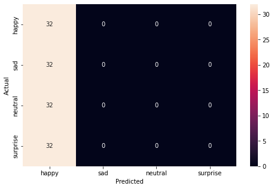

```
------Efficientnetmodel_1's performance-----
              precision    recall  f1-score   support

           0       0.50      0.56      0.53        32
           1       0.45      0.28      0.35        32
           2       0.42      0.69      0.52        32
           3       0.80      0.50      0.62        32

    accuracy                           0.51       128
   macro avg       0.54      0.51      0.50       128
weighted avg       0.54      0.51      0.50       128
```

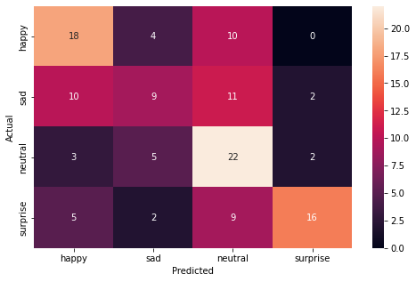

```python
# Plot the confusion matrix and generate a classification report for the model
from sklearn.metrics import classification_report
from sklearn.metrics import confusion_matrix
test_set = datagen_test.flow_from_directory(folder_path + "test",
                                                              target_size = (img_size,img_size),
                                                              color_mode = 'grayscale',
                                                              batch_size = 128,
                                                              class_mode = 'categorical',
                                                              classes = ['happy', 'sad', 'neutral', 'surprise'],
                                                              shuffle = True)
test_images, test_labels = next(test_set)

# Write the name of your chosen model in the blank
pred = Efficientnetmodel.predict(test_images)
pred = np.argmax(pred, axis = 1)
y_true = np.argmax(test_labels, axis = 1)

# Printing the classification report
print("------Efficientnetmodel's performance-----")
print(classification_report(y_true, pred))

# Plotting the heatmap using confusion matrix
cm = confusion_matrix(y_true, pred)
plt.figure(figsize = (8, 5))
sns.heatmap(cm, annot = True,  fmt = '.0f', xticklabels = ['happy', 'sad', 'neutral', 'surprise'], yticklabels = ['happy', 'sad', 'neutral', 'surprise'])
plt.ylabel('Actual')
plt.xlabel('Predicted')
plt.show()



test_images, test_labels = next(test_set)

# Write the name of your chosen model in the blank
pred = Efficientnetmodel_1.predict(test_images)
pred = np.argmax(pred, axis = 1)
y_true = np.argmax(test_labels, axis = 1)

# Printing the classification report
print("------Efficientnetmodel_1's performance-----")
print(classification_report(y_true, pred))

# Plotting the heatmap using confusion matrix
cm = confusion_matrix(y_true, pred)
plt.figure(figsize = (8, 5))
sns.heatmap(cm, annot = True,  fmt = '.0f', xticklabels = ['happy', 'sad', 'neutral', 'surprise'], yticklabels = ['happy', 'sad', 'neutral', 'surprise'])
plt.ylabel('Actual')
plt.xlabel('Predicted')
plt.show()
```

**Observations and Insights:__**  
Efficientnetmodel is classifying everything under'happy' label. So Efficientnetmodel is absolutely at its raw stage, and it needs lot of work for being good model.

Efficientnetmodel_1 is clearly doing better job than the previous model. It is missclassifying some labels but with more fine tuning and architectural modification we can improve this model.

**Note: You can even go back and build your own architecture on top of the VGG16 Transfer layer and see if you can improve the performance.**

**Think About It:**

- What is your overall performance of these Transfer Learning Architectures? Can we draw a comparison of these models' performances. Are we satisfied with the accuracies that we have received?
- Do you think our issue lies with 'rgb' color_mode?

**Conclusion:**

We saw VGG16, ResNet and EfficientNet pretrained models. We used these models and built our own models on top of them. Though results are not very lucrative, but we got the idea that good results can be achieved and it is very much doable. We need to identify the correct layers/blocks to choose from the pretrained model, topping it with more layers if required, fine tuning the parameters, some more training and etc.

Cause for the poor result is the poor architecture. “RGB” channel produces more parameters, but it will not contribute to errors produced by the models.

More time is needed to study the architecture and come up with the final correct model.

Now that we have tried multiple pre-trained models, let's build a complex CNN architecture and see if we can get better performance.

## **Building a Complex Neural Network Architecture**

In this section, we will build a more complex Convolutional Neural Network Model that has close to as many parameters as we had in our Transfer Learning Models. However, we will have only 1 input channel for our input images.

## **Creating our Data Loaders**

In this section, we are creating data loaders which we will use as inputs to the more Complicated Convolutional Neural Network. We will go ahead with color_mode = 'grayscale'.

```python
batch_size  = 32
img_size = 48

datagen_train = ImageDataGenerator(horizontal_flip = True,
                                    brightness_range = (0., 2.),
                                    rescale = 1./255,
                                    shear_range = 0.3)

train_set = datagen_train.flow_from_directory(folder_path + "train",
                                              target_size = (img_size, img_size),
                                              color_mode = 'grayscale',
                                              batch_size = batch_size,
                                              class_mode = 'categorical',
                                              classes = ['happy', 'sad', 'neutral', 'surprise'],
                                              shuffle = True)


datagen_validation = ImageDataGenerator(horizontal_flip = True,
                                    brightness_range = (0., 2.),
                                    rescale = 1./255,
                                    shear_range = 0.3)

validation_set = datagen_validation.flow_from_directory(folder_path + "validation",
                                              target_size = (img_size, img_size),
                                              color_mode = 'grayscale',
                                              batch_size = batch_size,
                                              class_mode = 'categorical',
                                              classes = ['happy', 'sad', 'neutral', 'surprise'],
                                              shuffle = True)
datagen_test = ImageDataGenerator(horizontal_flip = True,
                                    brightness_range = (0., 2.),
                                    rescale = 1./255,
                                    shear_range = 0.3)

test_set = datagen_test.flow_from_directory(folder_path + "test",
                                              target_size = (img_size, img_size),
                                              color_mode = 'grayscale',
                                              batch_size = batch_size,
                                              class_mode = 'categorical',
                                              classes = ['happy', 'sad', 'neutral', 'surprise'],
                                              shuffle = True)
```

```
Found 15109 images belonging to 4 classes.
Found 4977 images belonging to 4 classes.
Found 128 images belonging to 4 classes.
```

### **Model Building**

- In this network, we plan to have 5 Convolutional Blocks
- Add first Conv2D layer with **64 filters** and a **kernel size of 2**. Use the 'same' padding and provide the **input shape = (48, 48, 1)**. Use **'relu' activation**.
- Add your BatchNormalization layer followed by a LeakyRelU layer with Leaky ReLU parameter of **0.1**
- Add MaxPooling2D layer with **pool size = 2**.
- Add a Dropout layer with a Dropout Ratio of **0.2**. This completes the first Convolutional block.
- Add a second Conv2D layer with **128 filters** and a **kernel size of 2**. Use the **'same' padding** and **'relu' activation.**
- Follow this up with a similar BatchNormalization, LeakyRelU, Maxpooling2D, and Dropout layer like above to complete your second Convolutional Block.
- Add a third Conv2D layer with **512 filters** and a **kernel size of 2**. Use the **'same' padding** and **'relu' activation.** Once again, follow it up with a BatchNormalization, LeakyRelU, Maxpooling2D, and Dropout layer to complete your third Convolutional block.
- Add a fourth block, with the Conv2D layer having **512 filters**.
- Add the fifth block, having **128 filters**.
- Then add your Flatten layer, followed by your Dense layers.
- Add your first Dense layer with **256 neurons** followed by a BatchNormalization layer, a **'relu'** Activation, and a Dropout layer. This forms your first Fully Connected block
- Add your second Dense layer with **512 neurons**, again followed by a BatchNormalization layer, **relu** activation, and a Dropout layer.
- Add your final Dense layer with 4 neurons.
- Compile your model with the optimizer of your choice.

```python
no_of_classes = 4

model3 = Sequential()

# Add 1st CNN Block
model3.add(Conv2D(64,(2,2),padding='same',input_shape=(48,48,1),activation='relu'))
model3.add(BatchNormalization())
model3.add(LeakyReLU(alpha=0.1))
model3.add(MaxPooling2D())
model3.add(Dropout(0.2))
# Add 2nd CNN Block
model3.add(Conv2D(128,(2,2),padding='same',activation='relu'))
model3.add(BatchNormalization())
model3.add(LeakyReLU(alpha=0.1))
model3.add(MaxPooling2D())
model3.add(Dropout(0.2))
# Add 3rd CNN Block
model3.add(Conv2D(512,(2,2),padding='same',activation='relu'))
model3.add(BatchNormalization())
model3.add(LeakyReLU(alpha=0.1))
model3.add(MaxPooling2D())
model3.add(Dropout(0.2))
# Add 4th CNN Block
model3.add(Conv2D(512,(2,2)))
# Add 5th CNN Block
model3.add(Conv2D(128,(2,2)))
#flatten
model3.add(Flatten())
# First fully connected layer
model3.add(Dense(256,activation='relu'))
model3.add(BatchNormalization())
model3.add(Dropout(0.2))


model3.add(Dense(512,activation='relu'))
model3.add(BatchNormalization())
model3.add(Dropout(0.2))

model3.add(Dense(no_of_classes, activation = 'softmax'))
model3.summary()
```

```
Model: "sequential_11"
_________________________________________________________________
 Layer (type)                Output Shape              Param #
=================================================================
 conv2d (Conv2D)             (None, 48, 48, 64)        320

 batch_normalization_7 (Batc  (None, 48, 48, 64)       256
 hNormalization)

 leaky_re_lu (LeakyReLU)     (None, 48, 48, 64)        0

 max_pooling2d (MaxPooling2D  (None, 24, 24, 64)       0
 )

 dropout_6 (Dropout)         (None, 24, 24, 64)        0

 conv2d_1 (Conv2D)           (None, 24, 24, 128)       32896

 batch_normalization_8 (Batc  (None, 24, 24, 128)      512
 hNormalization)

 leaky_re_lu_1 (LeakyReLU)   (None, 24, 24, 128)       0

 max_pooling2d_1 (MaxPooling  (None, 12, 12, 128)      0
 2D)

 dropout_7 (Dropout)         (None, 12, 12, 128)       0

 conv2d_2 (Conv2D)           (None, 12, 12, 512)       262656

 batch_normalization_9 (Batc  (None, 12, 12, 512)      2048
 hNormalization)

 leaky_re_lu_2 (LeakyReLU)   (None, 12, 12, 512)       0

 max_pooling2d_2 (MaxPooling  (None, 6, 6, 512)        0
 2D)

 dropout_8 (Dropout)         (None, 6, 6, 512)         0

```

[output cut: 12 more lines]

```

 dense_67 (Dense)            (None, 512)               131584

 batch_normalization_11 (Bat  (None, 512)              2048
 chNormalization)

 dropout_10 (Dropout)        (None, 512)               0

 dense_68 (Dense)            (None, 4)                 2052

=================================================================
Total params: 2,271,300
Trainable params: 2,268,356
Non-trainable params: 2,944
_________________________________________________________________
```

### **Compiling and Training the Model**

```python
from keras.callbacks import ModelCheckpoint, ReduceLROnPlateau, CSVLogger

epochs = 35

steps_per_epoch = train_set.n//train_set.batch_size
validation_steps = validation_set.n//validation_set.batch_size

checkpoint = ModelCheckpoint("model3.h5", monitor = 'val_accuracy',
                            save_weights_only = True, model = 'max', verbose = 1)

reduce_lr = ReduceLROnPlateau(monitor = 'val_loss', factor = 0.1, patience = 2, min_lr = 0.0001 , model = 'auto')

callbacks = [checkpoint, reduce_lr]
```

```python
# Write your code to compile your model3. Use categorical crossentropy as the loss function,
#Adam Optimizer with 0.003 learning rate, and set metrics to 'accuracy'.
model3.compile(optimizer=Adam(0.003),
               loss='categorical_crossentropy',
               metrics=['accuracy'])
```

```python
# Write your code to fit your model.
#Use train_set as the training data and validation_set as the validation data.
#Train your model for 35 epochs.

history = model3.fit(train_set,epochs=35,
                     validation_data=validation_set,
                     callbacks=[callbacks])
```

```
Epoch 1: saving model to model3.h5
Epoch 2: saving model to model3.h5
Epoch 3: saving model to model3.h5
Epoch 4: saving model to model3.h5
Epoch 5: saving model to model3.h5
Epoch 6: saving model to model3.h5
Epoch 7: saving model to model3.h5
Epoch 8: saving model to model3.h5
Epoch 9: saving model to model3.h5
Epoch 10: saving model to model3.h5
Epoch 11: saving model to model3.h5
Epoch 12: saving model to model3.h5
Epoch 13: saving model to model3.h5
Epoch 14: saving model to model3.h5
Epoch 15: saving model to model3.h5
Epoch 16: saving model to model3.h5
Epoch 17: saving model to model3.h5
Epoch 18: saving model to model3.h5
Epoch 19: saving model to model3.h5
Epoch 20: saving model to model3.h5
Epoch 21: saving model to model3.h5
Epoch 22: saving model to model3.h5
Epoch 23: saving model to model3.h5
Epoch 24: saving model to model3.h5
Epoch 25: saving model to model3.h5
Epoch 26: saving model to model3.h5
Epoch 27: saving model to model3.h5
Epoch 28: saving model to model3.h5
Epoch 29: saving model to model3.h5
Epoch 30: saving model to model3.h5
Epoch 31: saving model to model3.h5
Epoch 32: saving model to model3.h5
Epoch 33: saving model to model3.h5
Epoch 34: saving model to model3.h5
Epoch 35: saving model to model3.h5
```

### **Evaluating the Model on Test Set**

```python
# Write your code to evaluate the model performance on the test set
model3.evaluate(test_set)
```

```
[1.5154154300689697, 0.6328125]
```

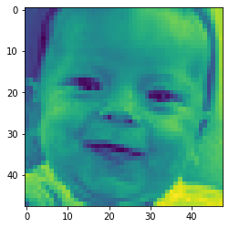

```
         Happy Face
Model3's prediction= happy
```

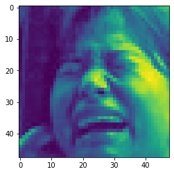

```
         Sad Face
Model3's prediction= happy
```

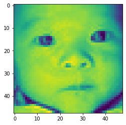

```
         Neutral Face
Model3's prediction= neutral
```

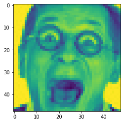

```
         Surprise Face
Model3's prediction= surprise
```

```python
# lets predict the face expression.
# will provide images for each expression (happy,sad,surprise and neutral)

#Predict images with model3
from keras_preprocessing.image import load_img
from keras_preprocessing.image import img_to_array
from keras.applications.vgg16 import preprocess_input

label_map = (test_set.class_indices)

imageHH = load_img('15730.jpg', target_size=(48, 48,1),color_mode='grayscale')
imageH = img_to_array(imageHH)
imageH /= 255
imageH = np.expand_dims(imageH, axis=0)
plt.imshow(imageHH)
plt.show()
print("         Happy Face          ")
pred = model3.predict(imageH)
print("Model3's prediction=",list(label_map.keys())[list(label_map.values()).index(np.argmax(pred))])

imageSDD = load_img('6992.jpg', target_size=(48, 48,1),color_mode='grayscale') #Load image
imageSD = img_to_array(imageSDD) # Convert to numpy array
imageSD /= 255
imageSD = np.expand_dims(imageSD, axis=0)
plt.imshow(imageSDD)
plt.show()
print("         Sad Face          ")
pred = model3.predict(imageSD)

print("Model3's prediction=",list(label_map.keys())[list(label_map.values()).index(np.argmax(pred))])



imageNN = load_img('7278.jpg', target_size=(48, 48,1),color_mode='grayscale') #Load image
imageN = img_to_array(imageNN) # Convert to numpy array
imageN /= 255
imageN = np.expand_dims(imageN, axis=0)
plt.imshow(imageNN)
plt.show()
print("         Neutral Face          ")
pred = model3.predict(imageN)

print("Model3's prediction=",list(label_map.keys())[list(label_map.values()).index(np.argmax(pred))])



imageSRR = load_img('208.jpg', target_size=(48, 48,1),color_mode='grayscale') #Load image
imageSR = img_to_array(imageSRR) # Convert to numpy array
imageSR /= 255
imageSR = np.expand_dims(imageSR, axis=0)
plt.imshow(imageSRR)
plt.show()
print("         Surprise Face          ")
pred = model3.predict(imageSR)

print("Model3's prediction=",list(label_map.keys())[list(label_map.values()).index(np.argmax(pred))])
```

**Model3's performance**

If we compare model3 with other models which were built before then model3 is outperforming all of them with better accuracy and prediction.

**New model (model3_extension):** Now, lets build another model using model3 as our base model.

```python
#save model3
model3.save('model3.h5')
```

```python
from tensorflow import keras
reconstructed_model = keras.models.load_model("model3.h5")

l=reconstructed_model.get_layer('conv2d_3')
x=Flatten()(l.output)

#adding one more layer
x=(Dense(1024,activation='relu'))(x)
x=(BatchNormalization())(x)
x=(Dropout(0.2))(x)

pred=Dense(4,activation='softmax')(x)
model3_extension = Model(reconstructed_model.input, pred)
```

```python
model3_extension.compile(optimizer=Adam(0.001),metrics=['accuracy'],loss='categorical_crossentropy')
```

```python
history_ext = model3_extension.fit(train_set,validation_data=validation_set,epochs=35)
```

```python
model3_extension.evaluate(test_set)
```

```
[0.7476308941841125, 0.6796875]
```

Lets plot the accuracy level to compare both the models.

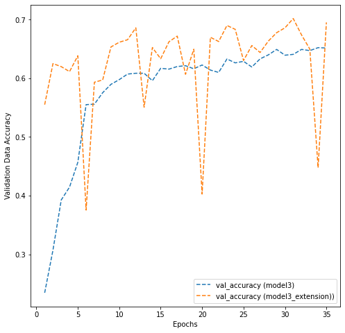

```python
# Plotting the accuracies

dict_hist = history.history
dict_hist_ext = history_ext.history

list_ep = [i for i in range(1, 36)]

plt.figure(figsize = (8, 8))

plt.plot(list_ep, dict_hist['val_accuracy'], ls = '--', label = 'val_accuracy (model3)')

plt.plot(list_ep, dict_hist_ext['val_accuracy'], ls = '--', label = 'val_accuracy (model3_extension))')
plt.ylabel('Validation Data Accuracy')

plt.xlabel('Epochs')

plt.legend()

plt.show()
```

```
Found 128 images belonging to 4 classes.
-------------------Model3--------------------
              precision    recall  f1-score   support

           0       0.67      0.62      0.65        32
           1       0.55      0.38      0.44        32
           2       0.51      0.69      0.59        32
           3       0.79      0.81      0.80        32

    accuracy                           0.62       128
   macro avg       0.63      0.62      0.62       128
weighted avg       0.63      0.62      0.62       128
```

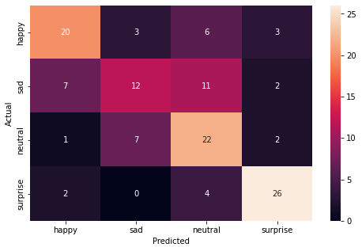

```
-------------------Model3_extension--------------------
              precision    recall  f1-score   support

           0       0.70      0.81      0.75        32
           1       0.47      0.59      0.53        32
           2       0.83      0.47      0.60        32
           3       0.82      0.84      0.83        32

    accuracy                           0.68       128
   macro avg       0.71      0.68      0.68       128
weighted avg       0.71      0.68      0.68       128
```

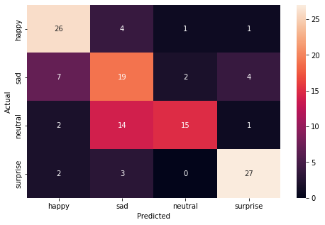

```python
# Plot the confusion matrix and generate a classification report for the model
from sklearn.metrics import classification_report
from sklearn.metrics import confusion_matrix
test_set = datagen_test.flow_from_directory(folder_path + "test",
                                                              target_size = (img_size,img_size),
                                                              color_mode = 'grayscale',
                                                              batch_size = 128,
                                                              class_mode = 'categorical',
                                                              classes = ['happy', 'sad', 'neutral', 'surprise'],
                                                              shuffle = True)

print("-------------------Model3--------------------")
test_images, test_labels = next(test_set)

# Write the name of your chosen model in the blank
pred = model3.predict(test_images)
pred = np.argmax(pred, axis = 1)
y_true = np.argmax(test_labels, axis = 1)

# Printing the classification report

print(classification_report(y_true, pred))

# Plotting the heatmap using confusion matrix
cm = confusion_matrix(y_true, pred)
plt.figure(figsize = (8, 5))
sns.heatmap(cm, annot = True,  fmt = '.0f', xticklabels = ['happy', 'sad', 'neutral', 'surprise'], yticklabels = ['happy', 'sad', 'neutral', 'surprise'])
plt.ylabel('Actual')
plt.xlabel('Predicted')
plt.show()

print("-------------------Model3_extension--------------------")
test_images, test_labels = next(test_set)

# Write the name of your chosen model in the blank
pred = model3_extension.predict(test_images)
pred = np.argmax(pred, axis = 1)
y_true = np.argmax(test_labels, axis = 1)

# Printing the classification report

print(classification_report(y_true, pred))

# Plotting the heatmap using confusion matrix
cm = confusion_matrix(y_true, pred)
plt.figure(figsize = (8, 5))
sns.heatmap(cm, annot = True,  fmt = '.0f', xticklabels = ['happy', 'sad', 'neutral', 'surprise'], yticklabels = ['happy', 'sad', 'neutral', 'surprise'])
plt.ylabel('Actual')
plt.xlabel('Predicted')
plt.show()
```

**Observations and Insights:__**

If we compare model3 and model3_extension then model3_extension is performing marginally better. It is having 4% more accuracy than model3. Both the models are having lots of scope for the improvement.

### **Plotting the Confusion Matrix for the chosen final model**

```
Found 128 images belonging to 4 classes.
              precision    recall  f1-score   support

           0       0.65      0.75      0.70        32
           1       0.54      0.69      0.60        32
           2       0.81      0.53      0.64        32
           3       0.90      0.81      0.85        32

    accuracy                           0.70       128
   macro avg       0.72      0.70      0.70       128
weighted avg       0.72      0.70      0.70       128
```

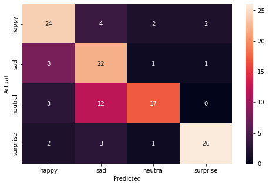

```python
# Plot the confusion matrix and generate a classification report for the model
from sklearn.metrics import classification_report
from sklearn.metrics import confusion_matrix
test_set = datagen_test.flow_from_directory(folder_path + "test",
                                                              target_size = (img_size,img_size),
                                                              color_mode = 'grayscale',
                                                              batch_size = 128,
                                                              class_mode = 'categorical',
                                                              classes = ['happy', 'sad', 'neutral', 'surprise'],
                                                              shuffle = True)
test_images, test_labels = next(test_set)

# Write the name of your chosen model in the blank
pred = model3_extension.predict(test_images)
pred = np.argmax(pred, axis = 1)
y_true = np.argmax(test_labels, axis = 1)

# Printing the classification report

print(classification_report(y_true, pred))

# Plotting the heatmap using confusion matrix
cm = confusion_matrix(y_true, pred)
plt.figure(figsize = (8, 5))
sns.heatmap(cm, annot = True,  fmt = '.0f', xticklabels = ['happy', 'sad', 'neutral', 'surprise'], yticklabels = ['happy', 'sad', 'neutral', 'surprise'])
plt.ylabel('Actual')
plt.xlabel('Predicted')
plt.show()
```

**Observations and Insights:__**

Among all these models, model3_extension is having better accuracy level. As confusion matrix suggests that in test data, each label is having 32 images and model is classifying correctly as mentioned below:

Label correct  
Happy 24  
Sad 22  
Neutral 17  
Surprise 26

## **Conclusion:*__***

After building many models , looking at their performances , accuracy level, prediction power, it can be said that no model is performing to the expectation level. Model3 and Model3_extension are better among all these models but still they are average performer. However all the models certainly need architectural modifications to perform better.

VGG16, ResNet and EfficientNet are pretrained image classifying models with high accuracy. Architecturally, they are different from each other but they all can be used for image classification problem.

Therefore, if we design or architect our model carefully using pretrained high performance models then we can achieve better result in less training and less time.

In any field, architecture is the key and here also we have to get the model architecture correct for satisfying result.

### **Refined insights**:

- What are the most meaningful insights from the data relevant to the problem?

### **Comparison of various techniques and their relative performance**:

- How do different techniques perform? Which one is performing relatively better? Is there scope to improve the performance further?

### **Proposal for the final solution design**:

- What model do you propose to be adopted? Why is this the best solution to adopt?